# Лабораторная работа 6. Метод ближайших соседей и наивный Байес

# Часть 1. Скажи мне, кто твои соседи

| столбец | что это |
| --- | --- |
| `km` | расстояние от ресторана до клиента, км |
| `traffic` | пробки в момент заказа, баллы (0 — пусто, 10 — город стоит) |
| `price` | сумма заказа, руб. |
| `late` | **курьер опоздал** (1 — да): ехал дольше обещанных 45 минут — это и угадываем |

600 заказов — для обучения, 200 — **тест**. Тест откроем один раз — в конце части 2. Сумму заказа пока не берём — вернёмся к ней в части 3.

**Что в коде ниже.** `train_test_split` делит таблицу на обучение и тест (как в лабе 5): `test_size=0.25` — четверть в тест, `stratify=...` — доля опозданий в обеих частях одинаковая, `random_state=0` — у всех делится одинаково. `X_...` — признаки (что знаем о заказе заранее), `y_...` — ответ (опоздал ли).

```python
orders = make_orders()
train, test = train_test_split(orders, test_size=0.25, random_state=0, stratify=orders["late"])
X_train, y_train = train[["km", "traffic"]], train["late"]
X_test, y_test = test[["km", "traffic"]], test["late"]
print("обучение:", len(train), " тест:", len(test), " доля опозданий в обучении:", round(y_train.mean(), 3))
train.head()
```

**Подумайте.** Пришёл новый заказ: **7 км, пробки 6 баллов**. Опоздает курьер или нет? Как решил бы опытный диспетчер?

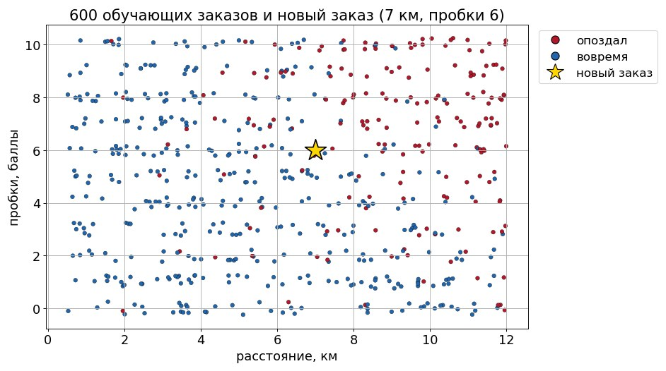

**Что видим.** Внизу слева (близко, пробок мало) — почти все синие: приехали вовремя. Вверху справа (далеко и пробки) — почти все красные. Посередине цвета перемешаны: там опоздание — дело случая (светофоры, погода, лифт).

**Проверить себя**

Новый заказ (звезда) — как раз на границе: по одному рисунку не решить. Диспетчер решил бы так: «посмотрю на **похожие** прошлые заказы — как они доехали?»

**Метод ближайших соседей** (kNN, *k nearest neighbors*) работает так:

1. находит `k` прошлых заказов, **ближайших** к новому на рисунке (расстояние — обычное, по линейке);
2. отвечает так, как было у **большинства** из них.

Учиться ему нечему: «обучение» — просто запомнить все 600 заказов. Вся работа — при ответе. Сначала — на маленьком примере из 16 заказов, где соседей видно глазами.

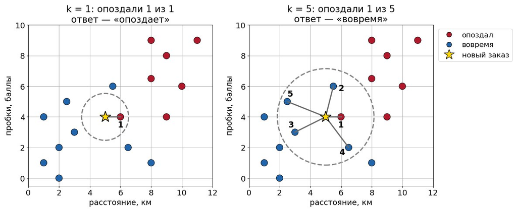

**Что видим.** Новый заказ — 5 км, пробки 4. Серые линии — расстояния до соседей, номера — кто ближе.

- `k = 1`: верим одному самому похожему. Он опоздал (может, сломался лифт) — ответ «опоздает».
- `k = 5`: спрашиваем пятерых. Четверо приехали вовремя — ответ «вовремя».

Один сосед может оказаться случайностью, большинство надёжнее.

Теперь — все 600 заказов и наш заказ (7 км, пробки 6). Глазами соседей уже не найти — посчитает sklearn.

**Новое в коде.**

| код | что делает |
| --- | --- |
| `KNeighborsClassifier(n_neighbors=5)` | создать модель «спроси 5 ближайших соседей» |
| `модель.fit(X, y)` | «обучить»: kNN просто запоминает таблицу заказов вместе с ответами |
| `модель.kneighbors(заказы)` | найти ближайших: расстояния до них и номера их строк в таблице |
| `модель.predict(заказы)` | ответ для каждого заказа: 1 — опоздает, 0 — вовремя (как большинство соседей) |
| `модель.predict_proba(заказы)` | доли голосов для каждого заказа: `[доля «вовремя», доля «опоздал»]` |

Например, в маленьком примере при `k = 5` (опоздал 1 из 5) `predict_proba` выдал бы `[0.8, 0.2]`, а `predict` — `0`.

```python
new_order = pd.DataFrame({"km": [7.0], "traffic": [6]})           # новый заказ — звезда на рисунке
knn5 = KNeighborsClassifier(n_neighbors=5).fit(X_train, y_train)   # «обучили» = запомнили таблицу
dist, idx = knn5.kneighbors(new_order)                             # расстояния и номера строк 5 ближайших
train.iloc[idx[0]].assign(расстояние=dist[0].round(2))             # эти строки таблицы + столбец «расстояние»
```

**✍ Задание.** Что ответит `knn5` про новый заказ? Посчитайте ответ (`predict`: 1 — опоздает, 0 — вовремя) и долю опоздавших среди соседей (`predict_proba`: второй столбец — доля класса 1).

Подсказка: обе функции отвечают сразу про все переданные заказы. `predict` даёт список ответов, по одному на заказ; заказ у нас один — берём первый элемент списка: `[0]` (нумерация с нуля). `predict_proba` даёт таблицу: строка — заказ, столбец — класс; `[0, 1]` — первый заказ, класс 1.

```python
# ✍ ЗАДАНИЕ НА СЕМИНАРЕ: ответ kNN для нового заказа
answer = ...            # 1 — опоздает, 0 — вовремя
share_late = ...   # доля опоздавших среди 5 соседей
if share_late is not ...:
    print("ответ:", answer, " доля опоздавших среди соседей:", share_late)
```

```python
# Проверка. Не меняйте эту ячейку.
check_1()
```

**Что видим.** Сколько из 5 соседей опоздали? Совпал ли ответ `knn5` с голосом большинства?

**Проверить себя**

Из 5 соседей опоздали 3 — доля 0.6, большинство за «опоздает». Предупредим клиента.

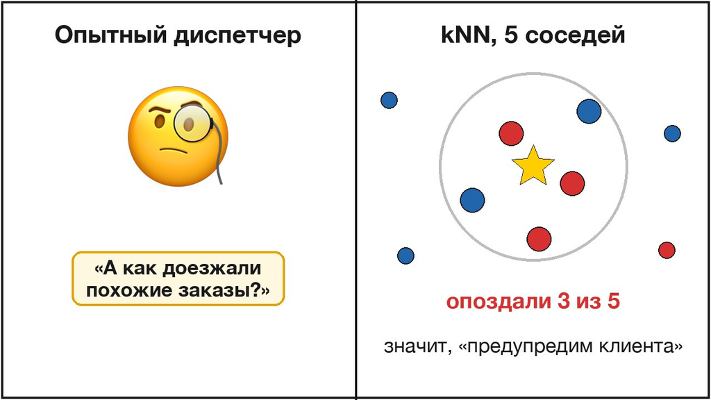

# Часть 2. Сколько соседей спросить

**Подумайте.** `k = 1` — верим одному самому похожему заказу. `k = 400` — спрашиваем две трети всех заказов. Что будет с долей верных на обучении и на новых заказах? На что это похоже из лабы 5?

Новых заказов нет, а тест трогать рано. Поэтому, как в лабе 5, — **кросс-валидация**: делим обучающие заказы на 5 блоков и 5 раз обучаем на четырёх, а проверяем на пятом.

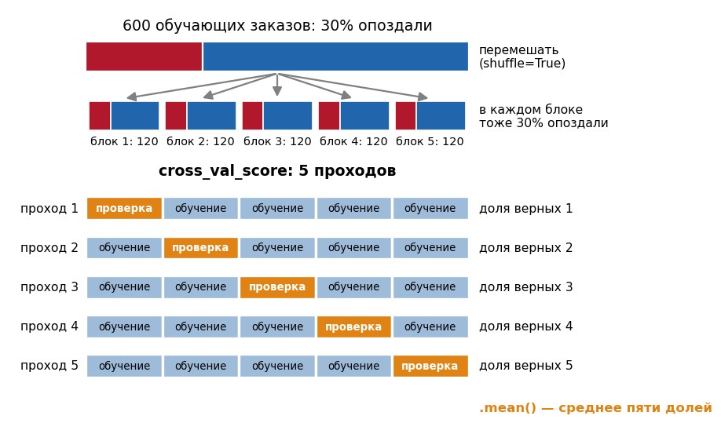

**Новое в коде.**

[output not shown]

**✍ Задание.** Соберём таблицу: для каждого `k` — доля верных на обучении (`score` на тех же данных, на которых обучали) и на «новых» заказах (кросс-валидация). По ней и выберем `k`. Допишите в цикле две строки.

```python
cv5 = StratifiedKFold(n_splits=5, shuffle=True, random_state=0)   # 5 блоков, номера перемешаны
# ✍ ЗАДАНИЕ НА СЕМИНАРЕ: доля верных для разного числа соседей
rows = []
for k in [1, 3, 5, 9, 15, 25, 45, 75, 150, 400]:
    model = KNeighborsClassifier(n_neighbors=k)
    acc_cv = ...   # средняя доля верных по кросс-валидации cv5 (как в лабе 5)
    model.fit(X_train, y_train)
    acc = ...   # доля верных на тех же данных, на которых обучали
    rows.append([k, acc, acc_cv])
by_k = pd.DataFrame(rows, columns=["соседей", "обучение", "кросс-вал."])
if acc is ... or acc_cv is ...:
    print("допишите две строки в цикле — тогда здесь будет таблица")
else:
    display(by_k.round(3))
```

```python
# Проверка. Не меняйте эту ячейку.
by_k = check_2()   # если таблица не сошлась — дальше идём по эталонной
```

```python
# @title Рисунок: доля верных от числа соседей
ax = by_k.astype(float).plot(x="соседей", y=["обучение", "кросс-вал."], logx=True, marker="o", lw=3, ms=10, figsize=(11, 6.8))
ax.axhline(1 - y_train.mean(), c="gray", ls="--", lw=2, label="«все приедут вовремя»")
ax.set_xticks(by_k["соседей"], [str(k) for k in by_k["соседей"]])
ax.minorticks_off()
ax.set(xlabel="число соседей k", ylabel="доля верных", title="Доля верных и число соседей")
ax.legend(loc="lower center")
plt.show()
```

[output not shown]

**✍ Задание.** Сколько соседей взять для новых заказов? Впишите `k` с **наибольшей долей по кросс-валидации** (по таблице или рисунку). И одной фразой: почему не 1 — ведь на обучении там 0.99?

```python
best_k = ...   # ✍ число соседей
# ✍ Почему не 1: ...
```

```python
# Проверка. Не меняйте эту ячейку.
best = check_best()   # best — k с наибольшей долей по кросс-валидации, пригодится дальше
```

**Что видим.** Обсудим вместе:

- почему у `k = 1` на обучении почти 1, а по кросс-валидации намного меньше?
- сильно ли отличаются доли от 9 до 150 соседей? Обязательно ли брать именно максимум?
- с чем совпадают обе доли при `k = 400` (серая линия на рисунке)?
- на что это похоже из лабы 5?

**Проверить себя**

- `k = 1`: на обучении 0.99 — каждый заказ сам себе ближайший сосед. По кросс-валидации — только 0.742: один сосед часто опоздал случайно.
- От 9 до 150 соседей — **плато** 0.84–0.87. Максимум у `k = 15`, но отрыв — несколько заказов из 600, это случайность: **годится любое `k` с плато**.
- `k = 400` — 0.695 и на обучении, и по кросс-валидации, ровно как ответ «все приедут вовремя»: среди 400 соседей опоздавших всегда меньше половины, и модель на всё отвечает «вовремя».

Это та же история, что с глубиной дерева в лабе 5: **мало соседей — зубрёжка** (переобучение), **слишком много — модель ничего не различает**. Число соседей выбирают по кросс-валидации.

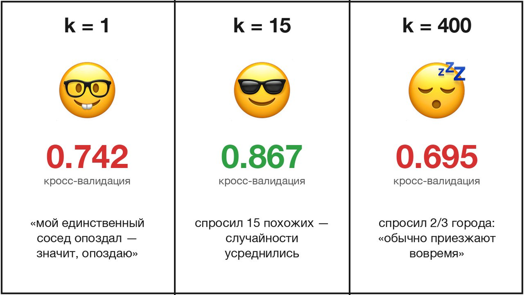

Как это выглядит? Закрасим каждое место рисунка цветом ответа kNN: розовым — где он скажет «опоздает», голубым — «вовремя».

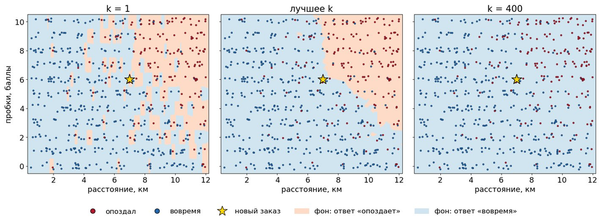

**Что видим.** Сравните три картинки:

- где модель выучила заказы наизусть?
- где граница плавная? Как она идёт: если пробки сильнее, то опоздать можно и на меньшем расстоянии — или нет?
- почему при `k = 400` розового нет совсем, хотя красных точек много?
- какого цвета место нашей звезды (7 км, пробки 6) при лучшем `k`? При `k = 5` ответ был «опоздает».

**Проверить себя**

- `k = 1` — пятнистая мозаика: вокруг каждого случайного опоздания своё розовое пятнышко. Модель выучила заказы наизусть.
- `k = 15` — плавная граница: «далеко **и** пробки — опоздает». Чем больше пробки, тем меньше километров нужно, чтобы опоздать.
- `k = 400` — всё голубое: голосуют две трети всех заказов, опоздавших среди них всегда меньше половины, и побеждает «вовремя». Модель ничего не различает.

Наша звезда при `k = 15` — в голубом: из 15 соседей опоздали 4, ответ «вовремя». При `k = 5` было «опоздает».

**Тест — один раз.** Число соседей выбрано, открываем тест: 200 заказов, которых модель не видела.

```python
for k in [1, best]:   # best — k с наибольшей долей по кросс-валидации (из ячейки проверки выше)
    model = KNeighborsClassifier(n_neighbors=k).fit(X_train, y_train)
    print(f"k = {k:2d}: доля верных на тесте {model.score(X_test, y_test):.3f}")
```

**Что видим.** Подтвердился ли на тесте выбор по кросс-валидации? (200 заказов — немного: разница в 1–2 процентных пункта была бы шумом.)

**Проверить себя**

На тесте `k = 15` угадывает 0.855, `k = 1` — 0.795. Выбор по кросс-валидации подтвердился. (200 заказов — немного: разница в 1–2 процентных пункта была бы шумом, а здесь 6 пунктов — 12 заказов.)

# Часть 3. Найди ошибку: сумма заказа в рублях

Коллега предлагает: «Добавим в модель сумму заказа — больше данных, модель станет только лучше». И пишет код:

```python
# код коллеги
X3_train = train[["km", "traffic", "price"]]
cv_colleague = cross_val_score(KNeighborsClassifier(n_neighbors=best), X3_train, y_train, cv=cv5).mean()
print("km + пробки:          ", round(by_k.loc[by_k["соседей"] == best, "кросс-вал."].item(), 3))
print("km + пробки + сумма:  ", round(cv_colleague, 3))
print("«все приедут вовремя»:", round(1 - y_train.mean(), 3))
```

**Подумайте.** С суммой заказа модель угадывает почти так же, как правило «все приедут вовремя». Почему? Где ошибка? Подсказка: посмотрите, кого kNN теперь считает соседями заказа «7 км, пробки 6 баллов, 1500 ₽».

```python
new3 = pd.DataFrame({"km": [7.0], "traffic": [6], "price": [1500.0]})
knn3 = KNeighborsClassifier(n_neighbors=best).fit(X3_train, y_train)
dist, idx = knn3.kneighbors(new3)
train.iloc[idx[0][:8]].assign(расстояние=dist[0][:8].round(1))
```

**Подумайте.** Что общего у этих «соседей»? Похожи ли они на новый заказ по километрам и пробкам? Чем измеряется сумма, а чем — километры и баллы?

**Проверить себя**

Все соседи — заказы почти на те же **1500 ₽**, а километры у них от 3 до 11.5 и пробки от 1 до 10 — какие угодно. Расстояние kNN считает по числам как есть: разница в 10 рублей весит столько же, сколько 10 километров. Суммы — это сотни и тысячи, километры и баллы — единицы, поэтому расстояние почти целиком определяет сумма заказа. kNN ищет соседей «по цене», а цена на опоздание не влияет. Километры и пробки модель просто не видит.

**Как исправить.** Привести признаки к одному масштабу. `StandardScaler` из каждого признака вычитает среднее и делит на разброс (стандартное отклонение): после этого у всех признаков типичные значения — от −2 до 2, и ни один не заглушает другие. На картинке — расстояние и сумма заказа глазами kNN: до масштаба и после.

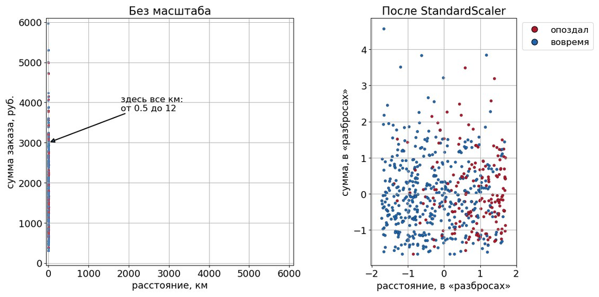

**Новое в коде.** `make_pipeline(StandardScaler(), KNeighborsClassifier(...))` склеивает скалер и kNN в одну модель (схема ниже). Дальше с ней всё как с обычной: `fit`, `predict`, `cross_val_score` — масштаб она наводит сама, по тем данным, на которых обучается.

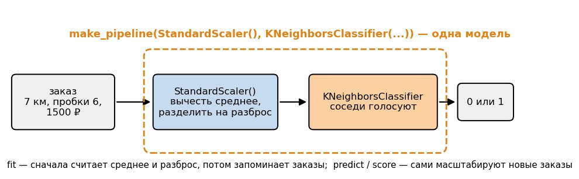

**✍ Задание.** Посчитайте долю верных по кросс-валидации `cv5` для модели «масштаб + kNN» на тех же трёх признаках `X3_train`; соседей — столько же, `best`.

```python
# ✍ ЗАДАНИЕ НА СЕМИНАРЕ: kNN с масштабированием
scaled_knn = ...   # масштаб + kNN с best соседями
cv_scaled = ...   # доля верных по кросс-валидации cv5
if cv_scaled is not ...:
    print("с масштабом:", cv_scaled)
```

```python
# Проверка. Не меняйте эту ячейку.
check_3()
```

**Что видим.**

- Насколько выросла доля с масштабом по сравнению с кодом коллеги?
- Стало ли лучше, чем совсем без суммы заказа? Почему?

**Проверить себя**

- С масштабом 0.848 вместо 0.705: километры и пробки снова «слышны».
- Но это всё равно чуть хуже, чем без суммы (0.867): сумма на опоздание не влияет, а в расстоянии участвует — и немного путает соседей.

**Правило:** для kNN признаки **всегда** приводят к одному масштабу (рубли, метры, проценты…), и бесполезные признаки ему вредят: «похожесть» считается по всем признакам сразу, нужным и ненужным. (В частях 1–2 обошлись без масштаба: у километров и баллов пробок разброс и так одинаковый — около 3.)

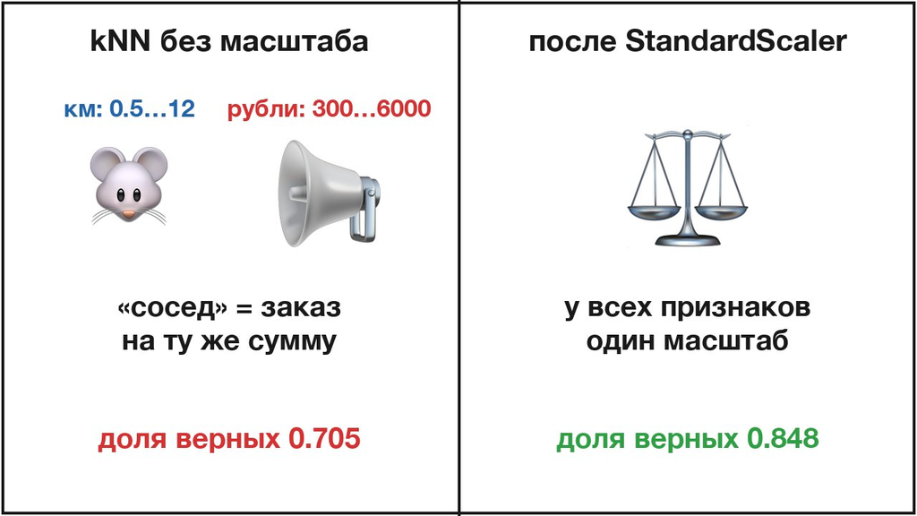

**Где kNN сегодня.** Идея «найди похожих» — в рекомендациях, поиске похожих фото и треков, в чат-ботах, отвечающих по документам (RAG). Объекты там — **эмбеддинги** (сотни чисел от нейросети, похожее — рядом), и всё так же решает, как мерить расстояние.

# Часть 4. Спам-фильтр: слова голосуют

Вторая история. Есть 600 SMS: 450 — для обучения, 150 — тест. Про каждое известно, спам это (1) или нет (0).

```python
# @title Данные: генератор сообщений (можно заглянуть)
HAM = ["привет как дела", "буду через 10 минут", "купи хлеба и молока", "во сколько встречаемся",
       "скинь конспект по матану", "мама просила позвонить", "я опаздываю на пару", "заберу тебя после работы",
       "спасибо за подарок", "в пятёрочке сегодня скидка на сыр", "скинь ссылку на зум", "пошли в кино вечером",
       "не забудь зарядку", "у меня сел телефон", "поздравляю с днём рождения", "ключи на столе",
       "давай завтра созвонимся", "семинар сегодня перенесли", "купил билеты на концерт, это будет огонь",
       "переведи мне 500 за пиццу", "кот опять разбил чашку, это ужас", "срочно перезвони", "как сдал экзамен",
       "посмотри фильм который я советовал", "забери посылку на почте",
       "оставил карту дома", "пришли код от домофона", "банк звонил про карту", "дарю тебе билет",
       "на кассе дали скидку", "напиши номер преподавателя", "получил зарплату", "сайт универа не работает",
       "сегодня скидка в кофейне", "перейди по ссылке там расписание", "позвони по номеру который я скинул"]
SPAM = ["вы выиграли приз", "заберите подарок прямо сейчас", "перейдите по ссылке", "только сегодня скидка 90%",
        "ваша карта заблокирована", "позвоните по номеру", "кредит одобрен без справок", "это бесплатно",
        "акция действует до конца дня", "получите выплату от государства", "подтвердите данные карты",
        "вы стали победителем розыгрыша", "срочно", "ваш аккаунт взломан", "казино дарит бонус 1000 рублей",
        "осталось 2 часа", "введите код из смс на сайте"]
FAKE = ["привет это мама", "у меня сел телефон", "переведи деньги на этот номер", "срочно", "потом объясню"]


def make_messages(n=600, seed=3):
    # выдуманные сообщения: каждое склеено из 1–3 готовых фраз; немного спама притворяется «своими»
    rng = np.random.default_rng([66, seed])
    spam = (rng.random(n) < 0.3).astype(int)                       # 1 — спам
    texts = []
    for s in spam:
        if s and rng.random() < 0.2:                                # мошенник пишет «от мамы»
            parts = list(rng.choice(FAKE, 2, replace=False)) + [rng.choice(HAM)]
        else:
            parts = list(rng.choice(SPAM if s else HAM, rng.integers(1, 4), replace=False))
            if s and rng.random() < 0.3:                            # спамер начинает «по-дружески»
                parts.insert(0, rng.choice(HAM))
        text = ". ".join(p[0].upper() + p[1:] for p in parts) + ("!" if s and rng.random() < 0.6 else "")
        texts.append(text)
    return pd.DataFrame({"text": texts, "spam": spam})
```

```python
messages = make_messages()
msg_train, msg_test = train_test_split(messages, test_size=0.25, random_state=0, stratify=messages["spam"])
print("обучение:", len(msg_train), " тест:", len(msg_test), " доля спама:", round(msg_train["spam"].mean(), 3))
pd.set_option("display.max_colwidth", 120)
msg_train.head(8)
```

**Подумайте.** По каким словам вы сразу узнаёте спам? Есть ли слова, которые бывают и в спаме, и в обычных сообщениях?

Компьютер текст не читает. Самое простое — **посчитать слова**: каждое сообщение превращается в строку таблицы, столбцы — все слова, которые встречались в обучении, в клетках — сколько раз слово есть в сообщении. Это делает `CountVectorizer` (большие буквы он делает маленькими, а слова из одной буквы — «я», «в» — пропускает).

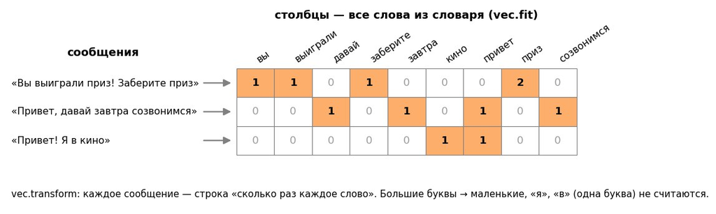

**Новое в коде.**

| код | что делает |
| --- | --- |
| `CountVectorizer()` | создать «счётчик слов» |
| `vec.fit(тексты)` | составить словарь — все слова, которые встретились в этих текстах |
| `vec.transform(тексты)` | каждый текст → строка счётчиков (как на картинке); слов не из словаря он не замечает |
| `vec.vocabulary_` | сам словарь: слово → номер столбца |

```python
vec = CountVectorizer().fit(msg_train["text"])            # запомнили словарь обучающих сообщений
W_train = vec.transform(msg_train["text"])                # таблица «сообщение × слово»
W_test = vec.transform(msg_test["text"])
print("слов в словаре:", len(vec.vocabulary_), "  таблица обучения (сообщений × слов):", W_train.shape)
```

**Наивный Байес** голосует словами:

- для каждого слова считает, как часто оно встречается в спаме и как часто — в обычных сообщениях;
- в новом сообщении каждое слово — **голос**: «бесплатно» встречается в спаме гораздо чаще — сильный голос за спам; «завтра» — чаще в обычных — голос против; «ссылке» встречается одинаково часто — голоса почти нет;
- голоса всех слов сводятся вместе с учётом того, что спама вообще около 30%, — получается вероятность «это спам».

**Наивный** — потому что каждое слово голосует отдельно, будто слова независимы.

**Новое в коде.**

| код | что делает |
| --- | --- |
| `MultinomialNB()` | создать наивный Байес для счётчиков слов |
| `модель.fit(W, y)` | «обучить»: посчитать, как часто каждое слово встречается в спаме и в обычных |
| `модель.predict(W)`, `модель.score(W, y)` | ответ (1 — спам) и доля верных — как у kNN |
| `модель.predict_proba(W)` | для каждого сообщения `[вероятность «обычное», вероятность «спам»]` |

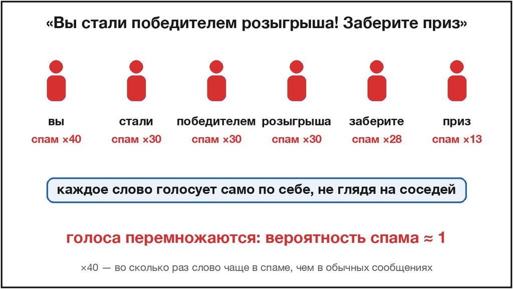

```python
nb = MultinomialNB().fit(W_train, msg_train["spam"])
print("доля верных на обучении:", round(nb.score(W_train, msg_train["spam"]), 3))
print("доля верных на тесте:   ", round(nb.score(W_test, msg_test["spam"]), 3))
print("«спама не бывает»:      ", round(1 - msg_test["spam"].mean(), 3))
```

**Что видим.** Фильтр угадывает 96% тестовых сообщений, а ответ «спама не бывает» — 69%. Голосование слов работает.

Какие слова голосуют сильнее всего? На картинке для каждого слова — **во сколько раз** оно чаще встречается в спаме, чем в обычных сообщениях (шкала неравномерная: 0.1, 1, 10 — на равных расстояниях).

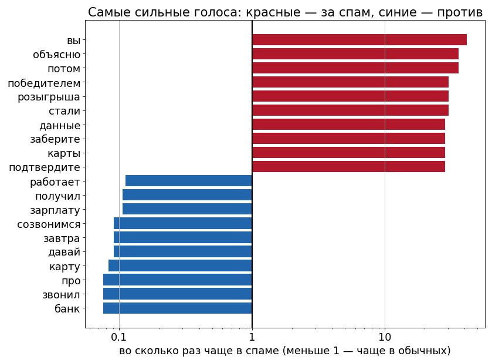

**Что видим.**

- Какое слово — самый сильный голос за спам? Как думаете, почему?
- Найдите на картинке «карты» и «карту». Почему у них разные голоса?
- Почему «объясню» — за спам, а «банк» — против?

**Проверить себя**

- Самый сильный голос за спам — «вы» (в 40 раз чаще в спаме): свои пишут на «ты», а спамеры — на «вы». Этого модели никто не говорил — она нашла сама.
- Против спама — например, «завтра», «давай», «созвонимся»: в 11 раз чаще в обычных.
- «карты» — за спам («подтвердите данные карты»), а «карту» — против («оставил карту дома»). Для модели это **разные слова**: она верит данным, а не смыслу.
- Слова ходят фразами: «потом объясню», «стали победителем», «подтвердите данные» — шаблоны спамеров, а «банк звонил про карту» в наших данных пишут свои. Поэтому «объясню» — за спам, а «банк» — против.

Где фильтр ошибся на тесте?

```python
pred = nb.predict(W_test)                  # ответы фильтра на тесте
wrong = pred != msg_test["spam"]           # True там, где фильтр ошибся
msg_test[wrong].assign(ответ_фильтра=pred[wrong])
```

**Что видим.** Сколько ошибок? Найдите спам «от мамы», который фильтр пропустил: почему он его не поймал? Какие слова в нём «домашние»?

**Проверить себя**

6 ошибок из 150. Например, «Привет это мама. Срочно. Забери посылку на почте» — мошенник, но пропущен: «забери посылку на почте» — четыре «домашних» голоса, и они перевесили (без этой фразы 0.92, с ней 0.20).

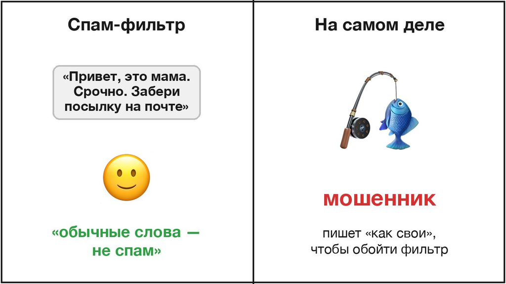

**✍ Задание.** Посчитайте вероятность «спам» для сообщения `"Привет! Сегодня скидка на пиццу, перейдите по ссылке"`. Сообщение нужно сначала превратить в строку таблицы тем же `vec`: `vec.transform([text])` — в квадратных скобках, потому что `transform` принимает **список** текстов (у нас он из одного). Потом `nb.predict_proba` — второй столбец, как в части 1.

```python
text = "Привет! Сегодня скидка на пиццу, перейдите по ссылке"
# ✍ ЗАДАНИЕ НА СЕМИНАРЕ: вероятность спама
p_spam = ...
if p_spam is not ...:
    print("вероятность спама:", p_spam)
```

```python
# Проверка. Не меняйте эту ячейку.
check_4()
```

**Что видим.** Фильтр уверен или сомневается? Какие слова этого сообщения голосуют за спам, а какие против?

**Проверить себя**

0.70 — фильтр сомневается: «перейдите» голосует за спам (в 20 раз чаще там), а «сегодня», «скидка» и «пиццу» — против: их чаще пишут в обычных («сегодня скидка в кофейне»).

**Почему наивный.** Каждое повторение слова — ещё один голос. Сравните:

```python
# @title Опыт: одно слово несколько раз (достаточно запустить)
def spam_probability(t):
    return nb.predict_proba(vec.transform([t]))[0, 1]


for t in ["Срочно", "Срочно срочно", "Срочно срочно срочно срочно"]:
    print(f"{t:30s} вероятность спама: {spam_probability(t):.3f}")
```

**Что видим.** Одно и то же слово, повторённое 4 раза, звучит для модели как 4 независимых свидетеля — уверенность растёт.

**✍ Задание (для себя, без проверки).** Напишите спам, который фильтр **пропустит** (вероятность меньше 0.5). Какой приём сработал?

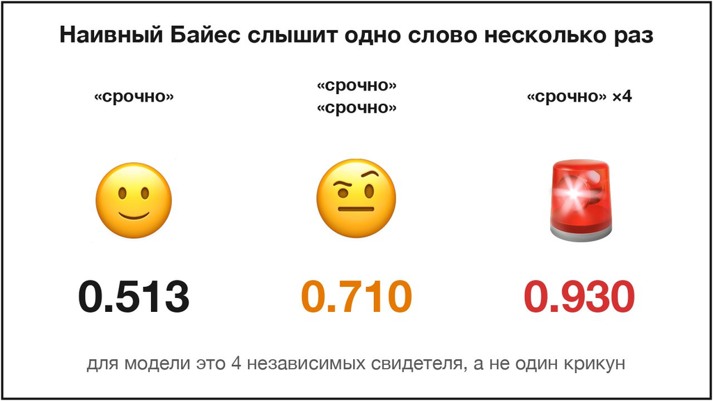

```python
# ✍ напишите свой спам
my_spam = "..."
if my_spam != "...":
    p = spam_probability(my_spam)
    print(f"вероятность спама {p:.3f}:", "фильтр обманут!" if p < 0.5 else "фильтр поймал — попробуйте ещё")
```

**Где Байес сегодня.** На нём работали первые спам-фильтры почты. Сейчас текст лучше понимают нейросети, но Байес остался **быстрым бейзлайном**: если большая нейросеть не обгоняет наивного Байеса — с ней что-то не так.

# Что запомнить

**Открыть после заданий**

- **kNN** ищет `k` самых похожих объектов и отвечает, как большинство. Учиться ему нечему — он помнит всю выборку.
- Мало соседей (`k = 1`) — зубрёжка: на обучении почти всё верно, по кросс-валидации намного хуже. Слишком много (`k = 400`) — всегда отвечает «вовремя», как большинство. `k` выбирают по кросс-валидации: годится любое с плато, точный максимум — дело случая.
- kNN сравнивает признаки по числам как есть: рубли заглушают километры. Признаки **масштабируют** (`StandardScaler` в одном `make_pipeline` с моделью), лишние признаки убирают.
- **Наивный Байес** превращает текст в счётчики слов и даёт каждому слову голос: во сколько раз оно чаще в спаме. Слова голосуют независимо — «наивно», но работает хорошо и быстро.
- Модель верит данным, а не смыслу: «вы» — спамное слово, «карты» и «карту» — разные слова, спам, разбавленный обычными словами, проходит фильтр.

# Домашняя работа 6

**Служба безопасности и поддержка банка.** У каждого свои данные (по фамилии). kNN ищет подозрительные переводы (рубли против часов, выбор `k`, тест один раз), наивный Байес раскладывает письма в поддержку по 4 отделам, а в «раскрываем карты» — как на самом деле устроены данные.